# Day 2- Data Visualization

8/13/2021

## Libraries

```r
library(sf) # load sf before tidyverse
library(tidyverse)
```

## Review functions

- `filter()`
- `select()`
- `mutate()`
- `group_by()`
- `summarise()`

## Analysis Workflow

## Tidyverse Workflow

[figure not shown]

[source](https://josiahparry.com/slides/tidymodels/xaringan.html)

## `ggplot2` motivation

- [Hadley Wickham’s Book](https://ggplot2-book.org/)

[Presentation](https://www.cedricscherer.com/slides/2019-08-28-intro-ggplot-statsizw#4)

## Data viz

- Understand your data
- Communicate your results

## ggplot2 structure

1. Data
2. Layers `geom_*()` and `stat_*()`
3. Aesthetics `aes()`
4. Scales `scale_*()`
5. Coordinate system `coord_*()`
6. Facets `facet_*()` arrangement of the data into a grid of plots
7. Visual themes `theme()` visual defaults

## ggplot2 structure

1. Data

## ggplot2 structure

1. Data
2. Layers `geom_*()` and `stat_*()`

## ggplot2 structure

1. Data
2. Layers `geom_*()` and `stat_*()`

[figure not shown]

## ggplot2 structure

1. Data
2. Layers `geom_*()` and `stat_*()`
3. Aesthetics `aes()`
- color, fill, alpha, size, shape.
- group

## ggplot2 structure

1. Data
2. Layers `geom_*()` and `stat_*()`
3. Aesthetics `aes()`
4. Scales `scale_*()`  
   position, colors, alpha, size, shape…

## ggplot2 structure

1. Data
2. Layers `geom_*()` and `stat_*()`
3. Aesthetics `aes()`
4. Scales `scale_*()`
5. Coordinate system `coord_*()`  
   compare `coord_cartesian()` to `scale_y_continuous()`

## ggplot2 structure

1. Data
2. Layers `geom_*()` and `stat_*()`
3. Aesthetics `aes()`
4. Scales `scale_*()`
5. Coordinate system `coord_*()`
6. Facets `facet_*()` arrangement of the data into a grid of plots

`facet_*`

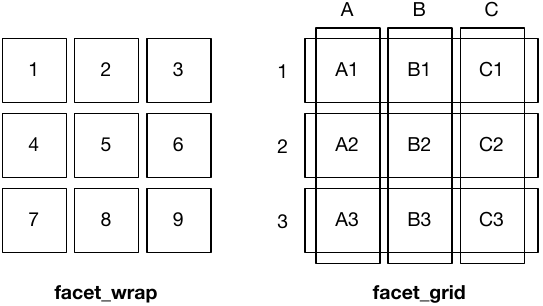

## ggplot2 structure

1. Data
2. Layers `geom_*()` and `stat_*()`
3. Aesthetics `aes()`
4. Scales `scale_*()`
5. Coordinate system `coord_*()`
6. Facets `facet_*()` arrangement of the data into a grid of plots
7. Visual themes `theme()` visual defaults

## Same data, different geoms:

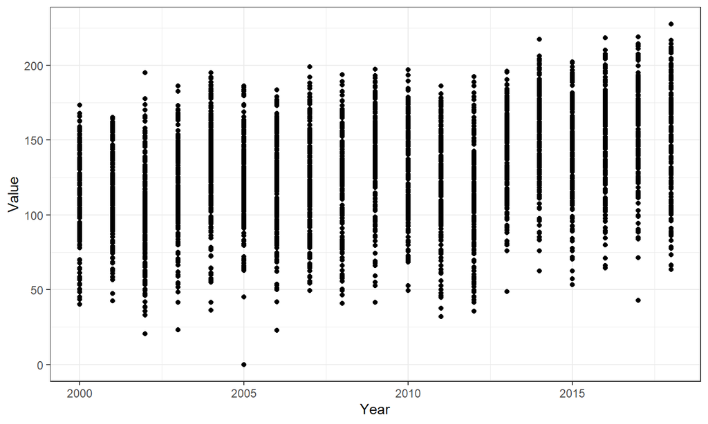

```r
usda <- read.csv("../data/USDAsurvey_00-18.csv")
usda %>%
  group_by(Year, State, Ag.District) %>%
  summarise_at(vars(Value), funs(mean)) %>%
  ggplot(aes(Year, Value))+
  geom_point()+
  theme_bw()
```

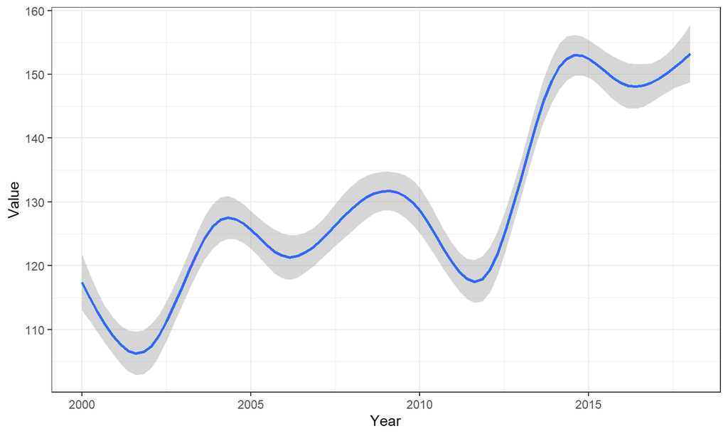

```r
usda %>%
  group_by(Year, State, Ag.District) %>%
  summarise_at(vars(Value), funs(mean)) %>%
  ggplot(aes(Year, Value))+
  geom_smooth()+
  theme_bw()
```

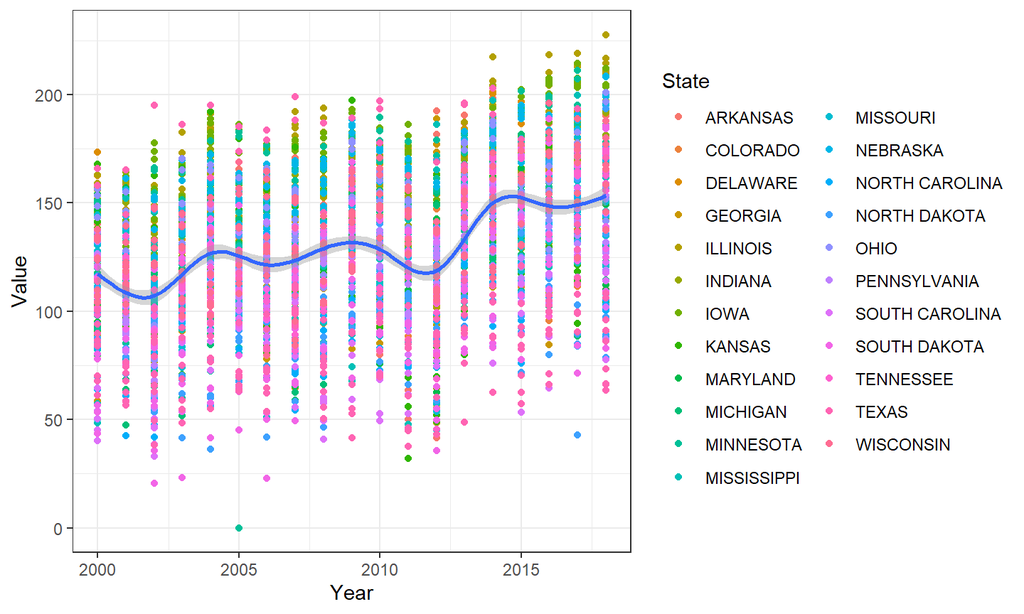

```r
usda %>%
  group_by(Year, State, Ag.District) %>%
  summarise_at(vars(Value), funs(mean)) %>%
  ggplot(aes(Year, Value))+
  geom_point(aes(color=State))+
  geom_smooth()+
  theme_bw()
```

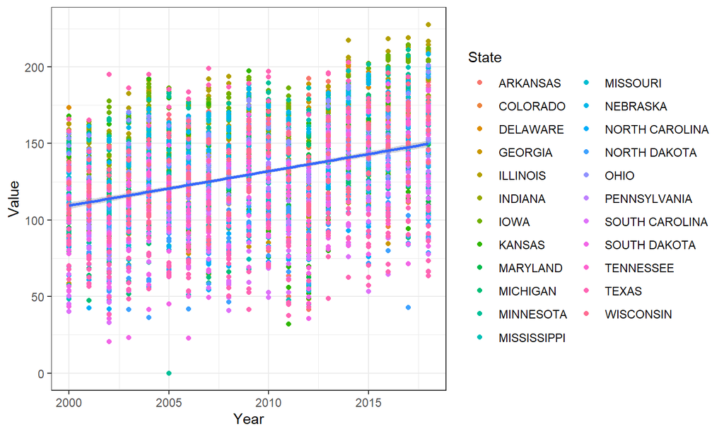

```r
usda %>%
  group_by(Year, State, Ag.District) %>%
  summarise_at(vars(Value), funs(mean)) %>%
  ggplot(aes(Year, Value))+
  geom_point(aes(color=State))+
  geom_smooth(method='lm')+
  theme_bw()
```

## Maps

```r
fao <- read.csv("../data/FAOSTAT_data_9-15-2021.csv")
```

```r
library(sf)
library(rnaturalearth)
library(rnaturalearthdata)
library(rgeos)
```

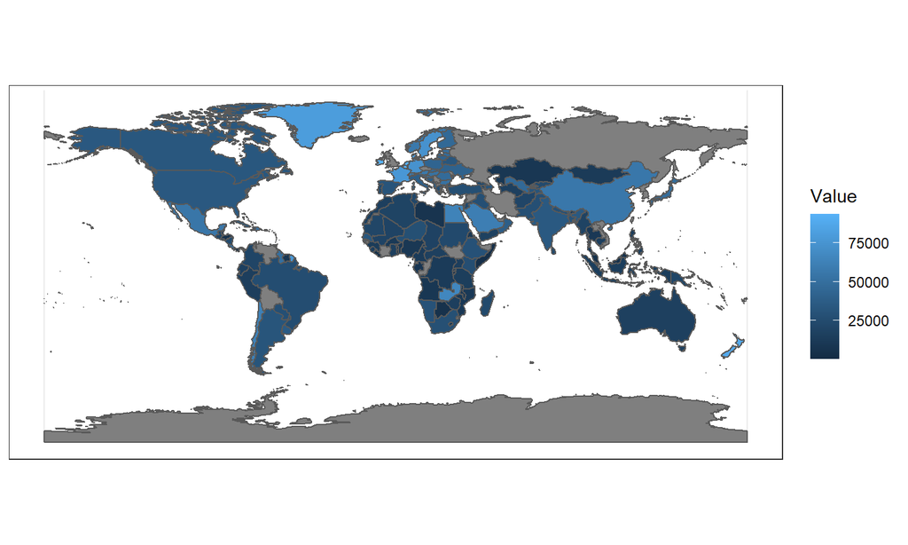

```r
world <- ne_countries(scale = "medium", returnclass = "sf")

### explain join_*() ###

world %>%
  left_join(fao %>% rename(sovereignt=Area)) %>%
  ggplot(aes(geometry=geometry))+
  geom_sf(aes(fill=Value))+
  theme_bw()
```

## Work in pairs

**A.** Load the file “lotus.csv” and answer these questions with visualizations.

```r
lotus <- read.csv("../data/lotus.csv")
```

- Are there any extreme values?
- What genotype has the greatest biomass?
- What treatment has the greatest biomass?

**B.** Use the USDA data and visualize a time series of:  
* Average country yields (i.e. axes: x = year, y = yield) with standard errors.  
* Average state yields (i.e. axes: x = year, y = yield) with standard errors. Here, plot 2 graphs: one with several lines, and one faceted for each state. Compare what each plot communicates.

## References

- [Font selection](https://medium.com/nightingale/choosing-a-font-for-your-data-visualization-2ed37afea637)
- [Color selection](https://coolors.co/ff7477-eac435-345995-03cea4-721817)